# Practical Machine Learning Project: Predicting Quality of Weight Lifting Exercise

Rhea Lucas

August 30, 2016

## Summary

This analysis aims to find a good model for predicting the quality of weight lifting exercises as part of the Practical Machine Learning class by Johns Hopkins University in Coursera. The data for this analysis was sourced from http://groupware.les.inf.puc-rio.br/har.

Based on comparison done between boosting and randomforest algorithm for predictions, it is apparent that randomforest performs better in predicting the quality of exercise.

## Loading and Exploring the Data

We are provided with a pml-training dataset to create and test the model and a pml-testing dataset where we are to validate our model one time. There are 160 variables in the dataset and the quality of the exercise which we are trying to predict is in the classe variable. After we load the data sets, we split the pml-training dataset further to training and testing sets which we will use for refining our model.

```r
pmlTraining <- read.csv("pml-training.csv", header = T, na.strings=c("NA", " ", ""))
pmlTesting <- read.csv("pml-testing.csv", header = T, na.strings=c("NA", " ", ""))

library(caret)
set.seed(123)
inTrain <- createDataPartition(y=pmlTraining$classe, p=0.6, list=FALSE)
training <- pmlTraining[inTrain,]
testing <- pmlTraining[-inTrain,]
```

We can now explore the training set to start making our model. The summary of the data (refer to appendix) shows that there are actually a lot of NA’s in some variables. In fact, if we try to look at the complete cases we have, there are only about 2% complete observations to work with.

```r
#Find out how many incomplete cases we have
compCases <- complete.cases(training)
table(compCases)
```

```
## compCases
## FALSE  TRUE
## 11528   248
```

If we look at variables containing more than 80% NA’s we see that they are actually NA for the same rows across the dataset where we have incomplete cases so it might be best to remove rather than impute for creating the model.

```r
#Find columns where 80% of the values are NA
NAcols <- colnames(training)[colSums(is.na(training)) > (.8*nrow(training))]

#check if NA across the same rows in the dataset where we have incomplete cases
all(is.na(training[!compCases, NAcols]))
```

```
## [1] TRUE
```

So now, we create a smaller dataset with NA columns removed along with the columns we identified as possible confounders and similarly subset out testing and validation sets.

We also know some variables in the dataset might not be good predictors as they are not related to the quality of the exercise and may end up confounding our predictions. For example, if we plot X, classe and user_name in the training dataset, we can see that the observations are ordered by X, with classe A exercises going first, and so on.

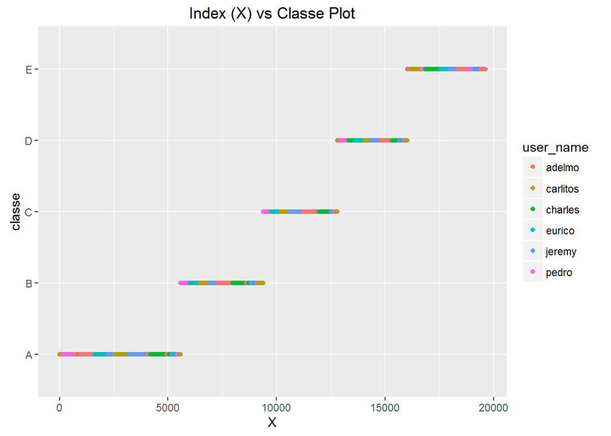

```r
library(ggplot2)
qplot(X, classe, data=training, color=user_name, main="Index (X) vs Classe Plot")
```

This is a pattern that we don’t necessarily want our model to pick up, so we also remove these variables when creating the model:

- X - index for the observations
- user_name - person performing the exercise
- raw_timestamp_part_1, raw_timestamp_part_2, cvtd_timestamp, new_window, num_window - variables related to when were the exercise performed

```r
#Create subset data frame with NA columns removed
trainingsub <- training[, !colSums(is.na(training)) > (.8*nrow(training))]
testingsub <- testing[, !colSums(is.na(training)) > (.8*nrow(training))]
validation <- pmlTesting[, !colSums(is.na(training)) > (.8*nrow(training))]

#Remove possible confounders found in column 1-7
trainingsub <- trainingsub[,8:60]
testingsub <- testingsub[,8:60]
validation <- validation[,8:60]
```

Finally we remove columns that are highly correlated. This is done by creating a correlation matrix then using the `findCorrelated` function from caret package which gives us the columns to remove from our dataset.

```r
#correlation matrix leaving out the classe variable
corMatrix <- cor(trainingsub[, 1:52])

#generate columns to remove
highlyCorrelated <- findCorrelation(corMatrix, cutoff=0.9, names = TRUE)

#remove highly correlated columns in all 3 datasets
trainingsub <- trainingsub[!(names(trainingsub) %in% highlyCorrelated)]
testingsub <- testingsub[!(names(testingsub) %in% highlyCorrelated)]
validation <- validation[!(names(validation) %in% highlyCorrelated)]
```

```r
set.seed(12345)

# use 10-fold cross validation as training control
train_control <- trainControl(method="cv", number=10)

#create boosting model
modgbm <- train(classe ~ ., data = trainingsub, method="gbm", trControl=train_control, verbose=F)

#create randomforest model
modrf <- train(classe ~ ., data = trainingsub, method="rf", trControl=train_control, verbose=F)
```

Now we can predict the values for our testing set using both models and compare the results.

```r
#predict classe for the testing set
predgbm <- predict(modgbm, testingsub)
predrf <- predict(modrf, testingsub)

#test accuracy for predictions
confgbm <- confusionMatrix(predgbm, testingsub$classe)
confrf <- confusionMatrix(predrf, testingsub$classe)
```

Looking at the results for both methods, we can see that the accuracy is pretty high for both (above 95%) with randomforest performing a bit better.

```r
#show accuracy and kappa
confgbm$overall
```

```
##       Accuracy          Kappa  AccuracyLower  AccuracyUpper   AccuracyNull
##   9.566658e-01   9.451862e-01   9.519241e-01   9.610644e-01   2.844762e-01
## AccuracyPValue  McnemarPValue
##   0.000000e+00   1.314255e-08
```

```r
confrf$overall
```

```
##       Accuracy          Kappa  AccuracyLower  AccuracyUpper   AccuracyNull
##      0.9909508      0.9885525      0.9885992      0.9929259      0.2844762
## AccuracyPValue  McnemarPValue
##      0.0000000            NaN
```

This is also apparent when we look at the prediction table where we see that randomforest had fewer errors in predictions. For both cases though, we have the most errors in predicting classe C exercise.

```r
#randomforest table
confrf$table
```

```
##           Reference
## Prediction    A    B    C    D    E
##          A 2228   12    0    0    0
##          B    4 1502   13    0    0
##          C    0    4 1344   16    5
##          D    0    0   11 1269    5
##          E    0    0    0    1 1432
```

```r
#boosting table
confgbm$table
```

```
##           Reference
## Prediction    A    B    C    D    E
##          A 2188   40    0    0    4
##          B   28 1429   64    5    9
##          C    9   44 1282   53   15
##          D    5    1   16 1219   26
##          E    2    4    6    9 1388
```

Finally, seeing that randomforest has better performance in predictions, we will now use this for predicting the classe variable for our validation set.

```r
predict(modrf, validation)
```

```
##  [1] B A B A A E D B A A B C B A E E A B B B
## Levels: A B C D E
```

Upon answering the quiz using this result set a 100% prediction (20/20) was the result.

## Appendix

Summary of training data:

```r
summary(training)
```

```
##        X            user_name    raw_timestamp_part_1 raw_timestamp_part_2
##  Min.   :    3   adelmo  :2338   Min.   :1.322e+09    Min.   :   294
##  1st Qu.: 4918   carlitos:1845   1st Qu.:1.323e+09    1st Qu.:252303
##  Median : 9808   charles :2154   Median :1.323e+09    Median :500339
##  Mean   : 9818   eurico  :1851   Mean   :1.323e+09    Mean   :501662
##  3rd Qu.:14732   jeremy  :2047   3rd Qu.:1.323e+09    3rd Qu.:756297
##  Max.   :19622   pedro   :1541   Max.   :1.323e+09    Max.   :998801
##
##           cvtd_timestamp new_window    num_window      roll_belt
##  28/11/2011 14:14: 892   no :11528   Min.   :  1.0   Min.   :-28.90
##  05/12/2011 11:24: 886   yes:  248   1st Qu.:223.0   1st Qu.:  1.10
##  30/11/2011 17:11: 870               Median :425.0   Median :113.00
##  02/12/2011 14:58: 853               Mean   :432.5   Mean   : 64.54
##  05/12/2011 11:25: 843               3rd Qu.:650.0   3rd Qu.:123.00
##  02/12/2011 14:57: 825               Max.   :864.0   Max.   :162.00
##  (Other)         :6607
##    pitch_belt          yaw_belt       total_accel_belt kurtosis_roll_belt
##  Min.   :-55.8000   Min.   :-179.00   Min.   : 0.00    #DIV/0!  :    5
##  1st Qu.:  1.8000   1st Qu.: -88.30   1st Qu.: 3.00    -1.908453:    2
##  Median :  5.2800   Median : -13.20   Median :17.00    -0.016850:    1
##  Mean   :  0.2876   Mean   : -11.25   Mean   :11.32    -0.021024:    1
##  3rd Qu.: 15.1000   3rd Qu.:  12.72   3rd Qu.:18.00    -0.025513:    1
##  Max.   : 60.3000   Max.   : 179.00   Max.   :28.00    (Other)  :  238
##                                                        NA's     :11528
##  kurtosis_picth_belt kurtosis_yaw_belt skewness_roll_belt
##  #DIV/0!  :   16     #DIV/0!:  248     #DIV/0!  :    4
##  47.000000:    4     NA's   :11528     0.000000 :    2
##  11.094417:    3                       0.422463 :    2
##  40.000000:    3                       -0.003095:    1
##  -2.060105:    2                       -0.010002:    1
##  (Other)  :  220                       (Other)  :  238
##  NA's     :11528                       NA's     :11528
##  skewness_roll_belt.1 skewness_yaw_belt max_roll_belt     max_picth_belt
##  #DIV/0!  :   16      #DIV/0!:  248     Min.   :-94.100   Min.   : 3.00
##  -6.324555:    3      NA's   :11528     1st Qu.:-88.000   1st Qu.: 5.00
##  0.000000 :    3                        Median : -4.950   Median :18.00
##  6.855655 :    3                        Mean   : -6.232   Mean   :13.03
##  -2.156553:    2                        3rd Qu.:  6.450   3rd Qu.:19.00
##  (Other)  :  221                        Max.   :180.000   Max.   :27.00
##  NA's     :11528                        NA's   :11528     NA's   :11528
```

[output cut: 305 more lines]

```
##  Min.   : -8.0900   Min.   :-498.0   Min.   :-632.00   Min.   :-391.00
##  1st Qu.: -0.1800   1st Qu.:-178.0   1st Qu.:  59.75   1st Qu.:-181.00
##  Median :  0.0800   Median : -57.0   Median : 201.00   Median : -38.00
##  Mean   :  0.1618   Mean   : -61.6   Mean   : 164.44   Mean   : -54.35
##  3rd Qu.:  0.4900   3rd Qu.:  78.0   3rd Qu.: 312.00   3rd Qu.:  27.00
##  Max.   :231.0000   Max.   : 477.0   Max.   : 923.00   Max.   : 287.00
##
##  magnet_forearm_x  magnet_forearm_y magnet_forearm_z classe
##  Min.   :-1280.0   Min.   :-896.0   Min.   :-973.0   A:3348
##  1st Qu.: -616.0   1st Qu.:  13.0   1st Qu.: 193.0   B:2279
##  Median : -380.0   Median : 595.0   Median : 512.0   C:2054
##  Mean   : -312.6   Mean   : 385.4   Mean   : 392.8   D:1930
##  3rd Qu.:  -73.0   3rd Qu.: 738.0   3rd Qu.: 654.0   E:2165
##  Max.   :  663.0   Max.   :1480.0   Max.   :1090.0
##
```